# From p.26

### 3.7.Statistical transformation

#### 3.7.1.What is the default geom associated with stat_summary()? How could you rewrite the previous plot to use that geom function instead of the stat function?

- Default geom is “geom_pointrange”

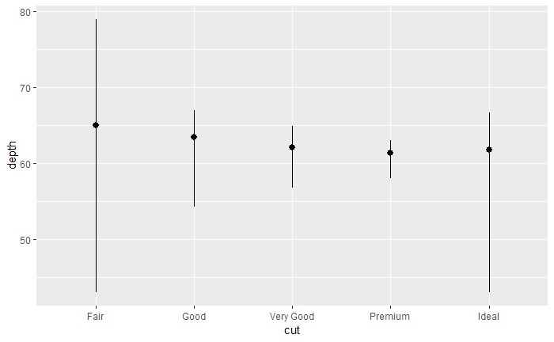

#### 3.7.2. What does geom_col() do? How is it different to geom_bar()?

- geom_col is function for drawing bar graph with single variable whereas geom_bar is function for drawing bar graph with two varible.
- In case of geom_col, since it only has single varible, argument **stat** automatically made another varible, “count” as default.

#### 3.7.3.Most geoms and stats come in pairs that are almost always used in concert. Read through the documentation and make a list of all the pairs. What do they have in common?

- 안할랭 귀차나

#### 3.7.4.What variables does stat_smooth() compute? What parameters control its behaviour?

- stat_smooth에 대해 알아보자
- 예시에서 확인하건데,
- 우선 se = standard deviation. 음영으로 표준편차 나옴. method는 어떠한 Smooth line을 그릴것 인가 하는 것인데, 아무것도 안정하면 loess(local smooth), lm for linear smooths, glm for generalised linear smooths, loess for local smooths 나머지.
- level 은 confidence lv. 안정하면 기본 0.95. 선은 어차피 안변하고 주위에 음영만 변함.
- span 은 method = lm 에서 폭을 정하는듯. 숫자가 커질수록 넓은 범위에서 스무딩이 이루어 지고, 낮을 수록 곡선이 막 빠빠빡 꺾인다.
- aes option중 fill은 음영의 색깔을 의미. alpha는 음영의 선명도를 의미. 0과 1 사이에서 존재. 1이 가장 진하다.

#### 3.7.5.In our proportion bar chart, we need to set group = 1. Why? In other words what is the problem with these two graphs?

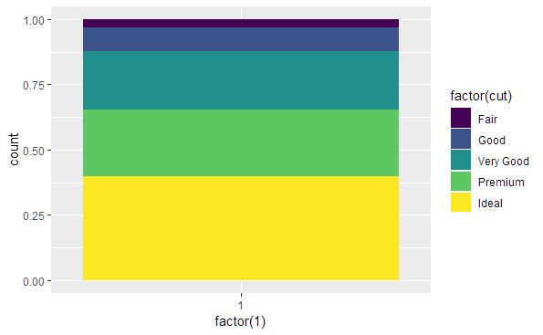